# UMN Applied Biostatistics Project: Clean Energy Industries and Mineral Demand

Jess Valiarovski

2025-01-21

# Introduction

This report analyzes mineral demand across various industry sectors using data from the **IEA Critical Minerals Dataset** ([IEA Website](https://www.iea.org/data-and-statistics/data-product/critical-minerals-dataset)). License: **CC BY 4.0**

# Abbreviations

- **MD** = Mineral Demand
- **sec** = Industry Sector
- **clm** = Column

# Load Required Libraries

```r
library(dplyr)      # Data manipulation
library(ggplot2)    # Visualization
library(tidyr)      # Data tidying
library(readxl)     # Read Excel files
library(forcats)    # Factor handling
library(janitor)    # Data cleaning
library(tidyverse)  # Data science suite
library(patchwork)  # Combining plots
library(stringr)    # String manipulation
library(broom)      # Linear Model summary
library(car)        # ANOVA
library(emmeans)    # Pairwise comparison
library(infer)      # permutation
library(multcomp)   # Post Hoc
library(multcompView) # Post Hoc
library(stringr)     # Splice character strings
```

# Load Dataset

```r
multiplesheets <- function(fname) {
  sheets <- readxl::excel_sheets(fname)
  tibble <- lapply(sheets, function(x) readxl::read_excel(fname, sheet = x))
  data_frame <- lapply(tibble, as.data.frame)
  names(data_frame) <- sheets
  return(data_frame)
}

path <- "CM_Data_Explorer May 2024.xlsx"
energy <- multiplesheets(path)
```

# Data Cleaning and Transformation

```r
MD_sec <- clean_names(energy[[4]])
#source: https://forum.posit.co/t/rename-columns-using-vector-of-names/181267
tidy_clm <- (c("Demand_by_sector","year_2023","empty1","Stated_Policies_Scenario_2030","year_2035",
               "year_2040","year_2045","year_2050","empty2","Announced_Pledges_Scenario_2030","year_2035.1","year_2040.1","year_2045.1","year_2050.1",
               "empty3","Net_Zero_Emissions_Scenario_2030","year_2035.2","year_2040.2","year_2045.2","year_2050.2"))
empty_clm <- c("empty1","empty2","empty3")
MD_sec <- MD_sec %>%
  setNames(tidy_clm) %>% #rename columns
  drop_na(`Demand_by_sector`) %>% #drop rows with no data
  dplyr::select(-any_of(empty_clm)) #remove spacer columns
MD_sec[,-1] <- apply(MD_sec[,-1],2,as.numeric) #convert response variable to numeric
MD_sec[,-1] <- round(MD_sec[,-1], digits = 3) #round the values to the 3rd digit
```

```r
sectors <- c("Other low emissions power generation", "Solar PV", "Low emissions power generation",
             "Hydrogen technologies", "Grid battery storage", "Electricity networks", "Electric vehicles") # list of clean energy industries

industry_MD <- subset(MD_sec, MD_sec$Demand_by_sector %in% sectors) %>%
  pivot_longer(cols = -Demand_by_sector, names_to = "year", values_to = "demand_kiloton_energy") %>%
  mutate(time = as.numeric(str_extract(year, "[0-9]{4}")),
         scenario = case_when(
           str_detect(year, "Announced_Pledges") ~ "Announced_Pledges",
           str_detect(year, "Net_Zero_Emissions") ~ "Net_Zero_Emissions",
           str_detect(year, "_2023") ~ "Now",
           TRUE ~ "Stated_Policies"
         )) %>%
   dplyr::select(-any_of("year"))
```

# Data Exploration

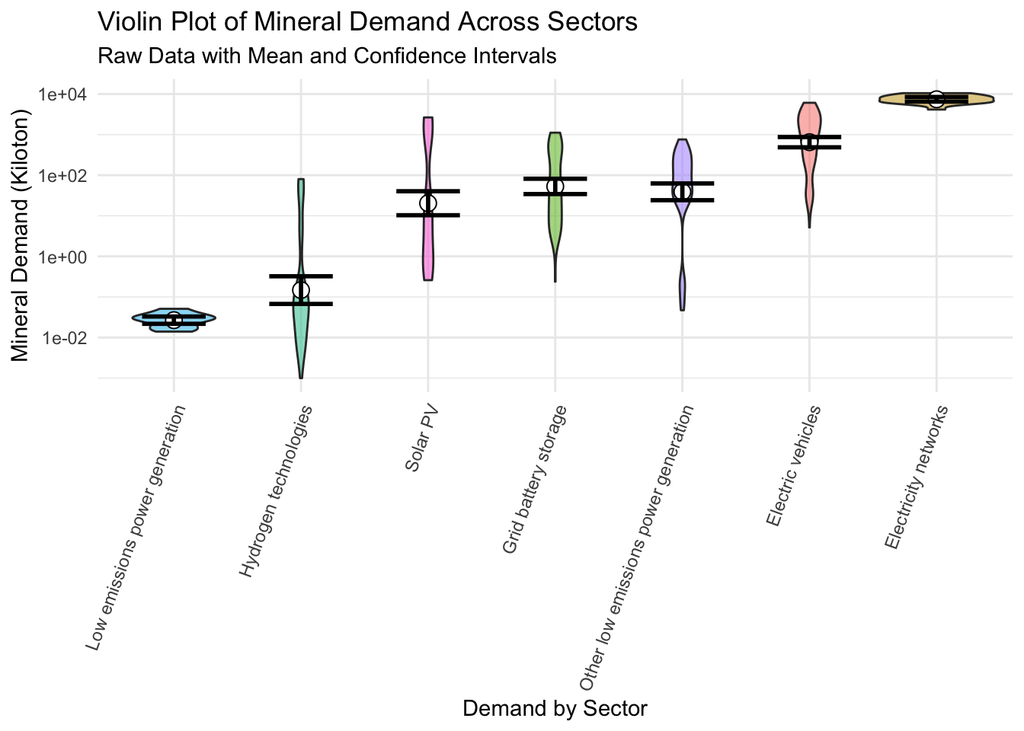

```r
energy_summary <- industry_MD %>%
  filter(scenario == "Now") %>%
  group_by(Demand_by_sector) %>%
  summarise(
    mean_energy = mean(demand_kiloton_energy, na.rm = TRUE),  # Mean mineral demand
    sd_energy = sd(demand_kiloton_energy, na.rm = TRUE),  # Standard deviation
    count = n(),  # Number of samples
    .groups = "drop"
  )



ggplot(industry_MD, aes(x = reorder(Demand_by_sector, demand_kiloton_energy, FUN = median),
                        y = demand_kiloton_energy,
                        fill = Demand_by_sector)) +
  geom_violin(trim = TRUE, alpha = 0.5, show.legend = FALSE) +
  stat_summary(fun = mean, geom = "point", shape = 21, size = 3.5, fill = "white", color = "black") +  # mean mineral demand
  stat_summary(fun.data = mean_cl_normal, geom = "errorbar", width = 0.5, size = 1, color = "black") +  # error bars
  scale_y_log10() +  # Normalize magnitudes with logarithm y-scale
  labs(title = "Violin Plot of Mineral Demand Across Sectors",
       subtitle = "Raw Data with Mean and Confidence Intervals",
       x = "Demand by Sector",
       y = "Mineral Demand (Kiloton)") +
  theme_minimal() +
  theme(axis.text.x = element_text(angle = 70, hjust = 1),
        legend.position = "right")
```

```r
energy_summary
```

```
## # A tibble: 7 × 4
##   Demand_by_sector                     mean_energy sd_energy count
##   <chr>                                      <dbl>     <dbl> <int>
## 1 Electric vehicles                        200.      242.        8
## 2 Electricity networks                    4143.       NA         1
## 3 Grid battery storage                      21.9      31.6       7
## 4 Hydrogen technologies                      0.241     0.476     4
## 5 Low emissions power generation             0.016    NA         1
## 6 Other low emissions power generation      57.7      59.0       7
## 7 Solar PV                                 389.      597.        6
```

```r
print(nrow(industry_MD %>%
  filter(scenario == "Now")))
```

```
## [1] 34
```

Electricity networks and low emissions power generation have only 1 sample representing the entire industry and will therefore be excluded from data analysis.

# Linear Analysis

### Logirthmatically transform data to correct residual variance

```r
# Linear Model
model_org <- lm(demand_kiloton_energy ~ Demand_by_sector, data = industry_MD %>% filter(scenario == "Now"))

# Extract residuals and sector information

residuals_data <- industry_MD %>%
  filter(scenario == "Now") %>%
  mutate(residuals = model_org$residuals)

# Plot QQ plots
resid_plot <- ggplot(residuals_data, aes(sample = residuals)) +
  stat_qq() +
  stat_qq_line() +
  facet_wrap(~ Demand_by_sector, scales = "free") +
  theme_minimal() +
  labs(
    title = "Original QQ Plots for Each Industry",
    x = "Theoretical Quantiles",
    y = "Sample Quantiles"
  )
```

Because our data shows a lack of homoscedasticity across categories, we do a logarithmic transform to minimize residual variability and make our type 2 ANOVA statistical test assumptions valid.

### Log Transformation for Normality

```r
log_industry_MD <- industry_MD %>%
  mutate(demand_kiloton_energy = log(demand_kiloton_energy + 1)) %>%
  filter(scenario == "Now")

# Filter out any levels with fewer than two observations
log_industry_MD_filtered <- log_industry_MD %>%
  filter(scenario == "Now") %>%
  group_by(Demand_by_sector) %>%
  filter(n() > 1)
```

Check QQ residual plots for improved homoscedasticity

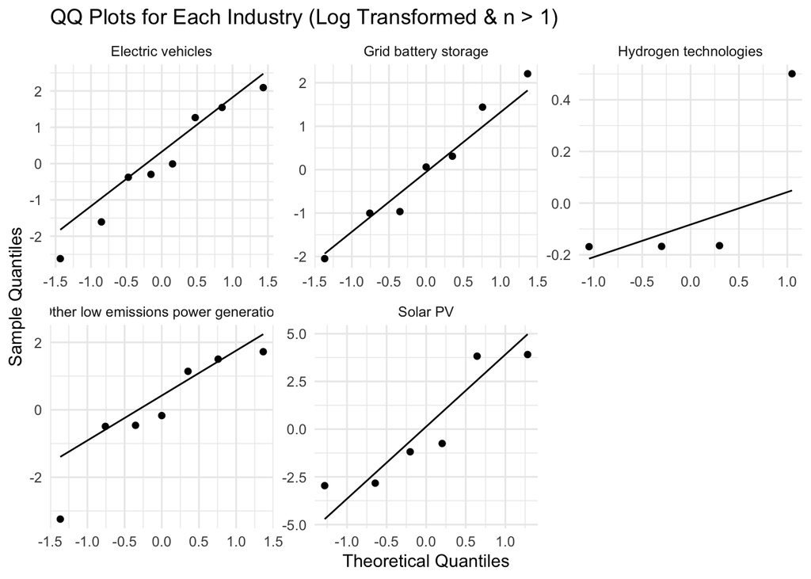

```r
# Fit the linear model
model <- lm(demand_kiloton_energy ~ Demand_by_sector, data = log_industry_MD_filtered)

# Compute residuals and merge back
residuals_data <- log_industry_MD_filtered %>%
  ungroup() %>%  # Ensure residuals are assigned correctly
  mutate(residuals = residuals(model))  # Compute residuals

# Create QQ plot
log_resid_plot <- ggplot(residuals_data, aes(sample = residuals)) +
  stat_qq() + stat_qq_line() +
  facet_wrap(~ Demand_by_sector, scales = "free") +
  theme_minimal() +
  labs(title = "QQ Plots for Each Industry (Log Transformed & n > 1)",
       x = "Theoretical Quantiles", y = "Sample Quantiles")

# Display the plot
log_resid_plot
```

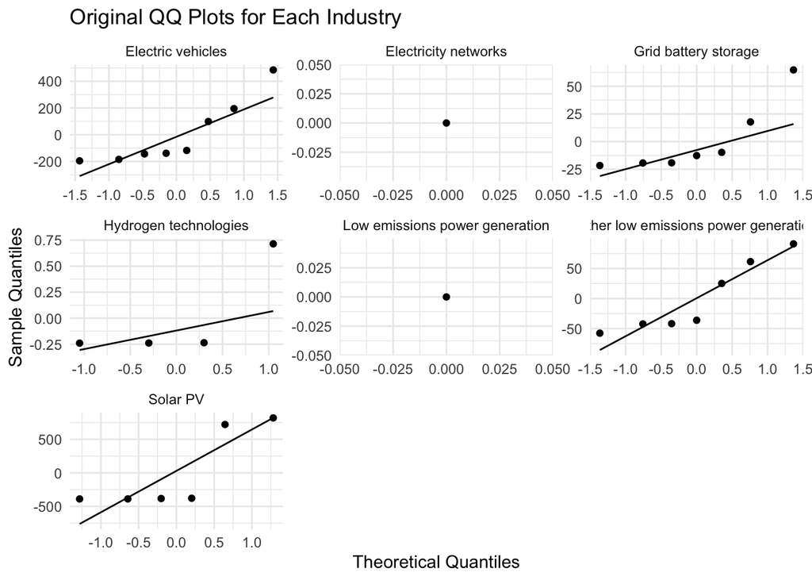

```r
resid_plot
```

Residual variability has decreased & the data is ready for ANOVA type 2 test.

### ANOVA Analysis

```r
Anova(model)
```

```
## Anova Table (Type II tests)
##
## Response: demand_kiloton_energy
##                  Sum Sq Df F value  Pr(>F)
## Demand_by_sector 53.063  4  3.6656 0.01647 *
## Residuals        97.714 27
## ---
## Signif. codes:  0 '***' 0.001 '**' 0.01 '*' 0.05 '.' 0.1 ' ' 1
```

The type 2 ANOVA test result tells us mineral demand can be predicted by the identity of the industry, with a sum of squares value of 53.063 and degrees of freedom of 4 with an unexplained variance of 97.714 in residual value (df = 27). The F value of this model is 3.6656 and the p-value of observing this F value is 0.01647, revealing that the industry sector identity is statistically significant (under the 5% null threshold) in determining differences in mineral demand.

## Pairwise Comparisons

```r
model_emmeans <- emmeans(model, ~ Demand_by_sector)
model_pairwise <- contrast(model_emmeans, method = "pairwise") %>%
  tidy()

model_pairwise <- model_pairwise %>%
  arrange(adj.p.value) %>%  # Sort from lowest to highest p-value
  mutate(cohens_d = abs(estimate / sd(log_industry_MD_filtered$demand_kiloton_energy))) %>%
  dplyr::select(-c(term,null.value))  # Remove the "term" column

print(model_pairwise, width = Inf)
```

```
## # A tibble: 10 × 7
##    contrast                                                     estimate
##    <chr>                                                           <dbl>
##  1 Electric vehicles - Hydrogen technologies                      4.27
##  2 Hydrogen technologies - Other low emissions power generation  -3.12
##  3 Hydrogen technologies - Solar PV                              -3.02
##  4 Electric vehicles - Grid battery storage                       2.17
##  5 Grid battery storage - Hydrogen technologies                   2.09
##  6 Electric vehicles - Solar PV                                   1.25
##  7 Electric vehicles - Other low emissions power generation       1.15
##  8 Grid battery storage - Other low emissions power generation   -1.02
##  9 Grid battery storage - Solar PV                               -0.927
## 10 Other low emissions power generation - Solar PV                0.0963
##    std.error    df statistic adj.p.value cohens_d
##        <dbl> <dbl>     <dbl>       <dbl>    <dbl>
##  1     1.16     27    3.66       0.00869   1.94
##  2     1.19     27   -2.61       0.0958    1.41
##  3     1.23     27   -2.46       0.130     1.37
##  4     0.985    27    2.21       0.207     0.986
##  5     1.19     27    1.76       0.419     0.950
##  6     1.03     27    1.21       0.744     0.565
##  7     0.985    27    1.17       0.769     0.522
##  8     1.02     27   -1.01       0.850     0.464
##  9     1.06     27   -0.876      0.903     0.420
## 10     1.06     27    0.0910     1.00      0.0437
```

```r
sig_groups <- cld(model_emmeans, adjust = "holm", Letters = "abcd", sort = TRUE, reversed = TRUE)
```

# Post Hoc Holm-Šídák Multiple Comparsion Test

```r
filtered_data <- log_industry_MD_filtered

sector_order <- filtered_data %>%
  group_by(Demand_by_sector) %>%
  summarise(mean_demand = mean(demand_kiloton_energy, na.rm = TRUE)) %>%
  arrange(mean_demand) %>%
  pull(Demand_by_sector)

filtered_data <- filtered_data %>%
  mutate(Demand_by_sector = factor(Demand_by_sector, levels = sector_order))

sig_groups <- sig_groups %>%
  filter(Demand_by_sector %in% unique(filtered_data$Demand_by_sector)) %>%
  mutate(Demand_by_sector = factor(Demand_by_sector, levels = sector_order))


# Create plot
pairwise_plot <- ggplot(filtered_data, aes(x = Demand_by_sector, y = demand_kiloton_energy, color = Demand_by_sector)) +
  geom_jitter(height = 0, width = .2, size = 4, alpha = .7, show.legend = FALSE) +
  stat_summary(fun.data = mean_cl_normal, geom = "errorbar", width = .2,
               position = position_nudge(x = .4), show.legend = FALSE) +
  geom_text(data = sig_groups, aes(label = .group, y = 4.5), size = 8, color = "black") +
  labs(title = "Significance Groupings in Industry Mineral Demand",
       x = "Demand by sector", y = "Energy demand (log kiloton)") +
  theme(axis.text.x = element_text(angle = 45, hjust = 1))
```

# Bootstrapped sampling distribution of energy demand across sectors

```r
# Order industries on graph based on mineral demand
sector_order <- log_industry_MD_filtered  %>%
  filter(scenario == "Now") %>%
  group_by(Demand_by_sector) %>%
  summarise(mean_demand = mean(demand_kiloton_energy)) %>%
  arrange(mean_demand) %>%
  pull(Demand_by_sector)  # Extract ordered sector names

# Apply the same order to both datasets
log_industry_MD_filtered$Demand_by_sector <- factor(log_industry_MD_filtered$Demand_by_sector, levels = sector_order)
sig_groups$Demand_by_sector <- factor(sig_groups$Demand_by_sector, levels = sector_order)

# Each time, we re sample our energy demand data within each industry sector.
#Then, we calculate the mean difference between each replicate.

# Compute the sample mean (for comparison)
sample_estimate <- log_industry_MD_filtered %>%
  group_by(Demand_by_sector) %>%  # Group by industry sector
  summarise(
    Mean = mean(demand_kiloton_energy, na.rm = TRUE),  # Compute mean
    Std_Error = sd(demand_kiloton_energy, na.rm = TRUE) / sqrt(n()),  # Compute standard error (SE)
    n = n()   ) %>% # Number of observations
  ungroup() %>%
  arrange(desc(Mean))

# Set number of bootstrap resamples
n_boots <- 1000

# Bootstrap sampling within each industry sector
industry_boot <- replicate(n = n_boots, simplify = FALSE,
                           expr = log_industry_MD_filtered  %>%
                             group_by(Demand_by_sector) %>%
                             slice_sample(prop = 1, replace = TRUE) %>%
                             summarise(mean_boot_kiloton_energy = mean(demand_kiloton_energy, na.rm = TRUE))) %>%
  bind_rows()

# Compute Bootstrapped Confidence Intervals
boot_dist_CI <- industry_boot %>%
  group_by(Demand_by_sector) %>%
  summarise(
    SE = sd(mean_boot_kiloton_energy),
    mean_kiloton_energy = mean(mean_boot_kiloton_energy),
    lower_95 = quantile(mean_boot_kiloton_energy, probs = 0.025),
    upper_95 = quantile(mean_boot_kiloton_energy, probs = 0.975)
  )
```

```r
boot_model <- lm(mean_boot_kiloton_energy ~ Demand_by_sector, data = industry_boot)
```

## Linear Model Analysis

```r
print(sample_estimate)
```

```
## # A tibble: 5 × 4
##   Demand_by_sector                      Mean Std_Error     n
##   <fct>                                <dbl>     <dbl> <int>
## 1 Electric vehicles                    4.44      0.568     8
## 2 Other low emissions power generation 3.29      0.646     7
## 3 Solar PV                             3.19      1.27      6
## 4 Grid battery storage                 2.26      0.561     7
## 5 Hydrogen technologies                0.170     0.167     4
```

```r
boot_summary <- summary(boot_model)$coefficients %>%
  as.data.frame() %>%
  rownames_to_column(var = "Variable") %>%
  mutate(Variable = str_remove(Variable, "Demand_by_sector")) %>%
  rename(
    Mean = Estimate,
    Std_Error = `Std. Error`,  # Standard Error
    t_test = `t value`,  # t-test
    p_value = `Pr(>|t|)`  # p-value
  ) %>%
  arrange(desc(abs(Mean)))  # Sort by mean

print(boot_summary)
```

```
##                               Variable      Mean  Std_Error     t_test
## 1                    Electric vehicles 4.2874033 0.02997324 143.041052
## 2 Other low emissions power generation 3.1189806 0.02997324 104.058852
## 3                             Solar PV 2.9877234 0.02997324  99.679707
## 4                 Grid battery storage 2.0975922 0.02997324  69.982174
## 5                          (Intercept) 0.1670916 0.02119428   7.883805
##        p_value
## 1 0.000000e+00
## 2 0.000000e+00
## 3 0.000000e+00
## 4 0.000000e+00
## 5 3.870539e-15
```

## ANOVA Analysis

```r
Anova(boot_model)
```

```
## Anova Table (Type II tests)
##
## Response: mean_boot_kiloton_energy
##                   Sum Sq   Df F value    Pr(>F)
## Demand_by_sector 10227.7    4  5692.2 < 2.2e-16 ***
## Residuals         2243.7 4995
## ---
## Signif. codes:  0 '***' 0.001 '**' 0.01 '*' 0.05 '.' 0.1 ' ' 1
```

## Pairwise Comparisons

```r
boot_model_emmeans <- emmeans(boot_model, ~ Demand_by_sector)
boot_model_pairwise <- contrast(boot_model_emmeans, method = "pairwise") %>%
  tidy()

boot_model_pairwise
```

```
## # A tibble: 10 × 8
##    term       contrast null.value estimate std.error    df statistic adj.p.value
##    <chr>      <chr>         <dbl>    <dbl>     <dbl> <dbl>     <dbl>       <dbl>
##  1 Demand_by… Hydroge…          0   -2.10     0.0300  4995    -70.0     0
##  2 Demand_by… Hydroge…          0   -2.99     0.0300  4995    -99.7     0
##  3 Demand_by… Hydroge…          0   -3.12     0.0300  4995   -104.      0
##  4 Demand_by… Hydroge…          0   -4.29     0.0300  4995   -143.      0
##  5 Demand_by… Grid ba…          0   -0.890    0.0300  4995    -29.7     0
##  6 Demand_by… Grid ba…          0   -1.02     0.0300  4995    -34.1     0
##  7 Demand_by… Grid ba…          0   -2.19     0.0300  4995    -73.1     0
##  8 Demand_by… Solar P…          0   -0.131    0.0300  4995     -4.38    0.000119
##  9 Demand_by… Solar P…          0   -1.30     0.0300  4995    -43.4     0
## 10 Demand_by… Other l…          0   -1.17     0.0300  4995    -39.0     0
```

# Post Hoc Significance Testing

```r
boot_sig_groups <- cld(boot_model_emmeans, adjust = "holm", Letters = "abcd", sort = TRUE, reversed = TRUE)
boot_sig_groups
```

```
##  Demand_by_sector                     emmean     SE   df lower.CL upper.CL
##  Electric vehicles                     4.454 0.0212 4995    4.400    4.509
##  Other low emissions power generation  3.286 0.0212 4995    3.231    3.341
##  Solar PV                              3.155 0.0212 4995    3.100    3.209
##  Grid battery storage                  2.265 0.0212 4995    2.210    2.319
##  Hydrogen technologies                 0.167 0.0212 4995    0.112    0.222
##  .group
##   a
##    b
##     c
##      da
##        db
##
## Confidence level used: 0.95
## Conf-level adjustment: bonferroni method for 5 estimates
## P value adjustment: holm method for 10 tests
## significance level used: alpha = 0.05
## NOTE: If two or more means share the same grouping symbol,
##       then we cannot show them to be different.
##       But we also did not show them to be the same.
```

```r
box_xmin_boot <- which(levels(boot_dist_CI$Demand_by_sector) == "Hydrogen technologies") - 0.5
box_xmax_boot <- which(levels(boot_dist_CI$Demand_by_sector) == "Electric vehicles") + 0.5

pairwise_boot_plot <- ggplot(industry_boot,
                        aes(x = Demand_by_sector, y = mean_boot_kiloton_energy, fill = Demand_by_sector)) +
  geom_violin(trim = TRUE, alpha = 0.5, show.legend = FALSE) +
   geom_errorbar(data = boot_dist_CI,
                aes(x = Demand_by_sector,
                    y = mean_kiloton_energy,
                    ymin = lower_95, ymax = upper_95),
                width = 0.2, size = 0.8, color = "black", show.legend = FALSE) +
  geom_text(data = boot_sig_groups, aes(label = .group, y = 4.5), size = 8, color = "black", vjust = -0.5) +
  labs(title = "2023 Clean Energy Industry Mineral Demand",
       subtitle = "Bootstrap Resampled 1000x",
       x = "Demand by Sector", y = "Energy Demand (Log Kiloton)") +
    annotate("rect", xmin = box_xmin_boot, xmax = box_xmax_boot, ymin = -Inf, ymax = Inf,
            fill = "gray", alpha = 0.2) +
  theme_minimal() +
  theme(axis.text.x = element_text(size = 10, angle = 70, hjust = 1)) +
  scale_y_continuous(limits = c(0, 9))
```

```r
pairwise_plot <- ggplot(log_industry_MD_filtered,
                        aes(x = Demand_by_sector, y = demand_kiloton_energy, fill = Demand_by_sector)) +
  geom_violin(trim = TRUE, alpha = 0.5, show.legend = FALSE) +
  geom_errorbar(data = sig_groups,
                aes(x = Demand_by_sector, ymin = emmean - SE, ymax = emmean + SE, color = Demand_by_sector),
                width = 0.2, size = 1.2, inherit.aes = FALSE) +

  geom_text(data = sig_groups, aes(label = .group, y = 4.5), size = 8, color = "black") +
  labs(title = "2023 Clean Energy Industry Mineral Demand",
       subtitle = "Original Sample",
       x = "Demand by Sector", y = "Energy Demand (log kiloton)") +
  theme(axis.text.x = element_text(angle = 45, hjust = 1)) +
  scale_y_continuous(limits = c(0, 9))
```

```r
print(sig_groups)
```

```
##                       Demand_by_sector    emmean        SE df   lower.CL
## 1                    Electric vehicles 4.4375029 0.6725915 27  2.5739653
## 2 Other low emissions power generation 3.2871829 0.7190305 27  1.2949773
## 3                             Solar PV 3.1908398 0.7766417 27  1.0390119
## 4                 Grid battery storage 2.2637248 0.7190305 27  0.2715192
## 5                Hydrogen technologies 0.1695938 0.9511880 27 -2.4658464
##   upper.CL .group
## 1 6.301041     a
## 2 5.279388     ab
## 3 5.342668     ab
## 4 4.255930     ab
## 5 2.805034      b
```

```r
summary(pairs(model_emmeans))
```

```
##  contrast                                                     estimate    SE df
##  Electric vehicles - Grid battery storage                       2.1738 0.985 27
##  Electric vehicles - Hydrogen technologies                      4.2679 1.160 27
##  Electric vehicles - Other low emissions power generation       1.1503 0.985 27
##  Electric vehicles - Solar PV                                   1.2467 1.030 27
##  Grid battery storage - Hydrogen technologies                   2.0941 1.190 27
##  Grid battery storage - Other low emissions power generation   -1.0235 1.020 27
##  Grid battery storage - Solar PV                               -0.9271 1.060 27
##  Hydrogen technologies - Other low emissions power generation  -3.1176 1.190 27
##  Hydrogen technologies - Solar PV                              -3.0212 1.230 27
##  Other low emissions power generation - Solar PV                0.0963 1.060 27
##  t.ratio p.value
##    2.208  0.2073
##    3.664  0.0087
##    1.168  0.7688
##    1.213  0.7438
##    1.756  0.4185
##   -1.006  0.8501
##   -0.876  0.9032
##   -2.615  0.0958
##   -2.460  0.1301
##    0.091  1.0000
##
## P value adjustment: tukey method for comparing a family of 5 estimates
```

```r
print(boot_sig_groups)
```

```
##  Demand_by_sector                     emmean     SE   df lower.CL upper.CL
##  Electric vehicles                     4.454 0.0212 4995    4.400    4.509
##  Other low emissions power generation  3.286 0.0212 4995    3.231    3.341
##  Solar PV                              3.155 0.0212 4995    3.100    3.209
##  Grid battery storage                  2.265 0.0212 4995    2.210    2.319
##  Hydrogen technologies                 0.167 0.0212 4995    0.112    0.222
##  .group
##   a
##    b
##     c
##      da
##        db
##
## Confidence level used: 0.95
## Conf-level adjustment: bonferroni method for 5 estimates
## P value adjustment: holm method for 10 tests
## significance level used: alpha = 0.05
## NOTE: If two or more means share the same grouping symbol,
##       then we cannot show them to be different.
##       But we also did not show them to be the same.
```

```r
summary(pairs(boot_model_emmeans))
```

```
##  contrast                                                     estimate   SE
##  Hydrogen technologies - Grid battery storage                   -2.098 0.03
##  Hydrogen technologies - Solar PV                               -2.988 0.03
##  Hydrogen technologies - Other low emissions power generation   -3.119 0.03
##  Hydrogen technologies - Electric vehicles                      -4.287 0.03
##  Grid battery storage - Solar PV                                -0.890 0.03
##  Grid battery storage - Other low emissions power generation    -1.021 0.03
##  Grid battery storage - Electric vehicles                       -2.190 0.03
##  Solar PV - Other low emissions power generation                -0.131 0.03
##  Solar PV - Electric vehicles                                   -1.300 0.03
##  Other low emissions power generation - Electric vehicles       -1.168 0.03
##    df  t.ratio p.value
##  4995  -69.982  <.0001
##  4995  -99.680  <.0001
##  4995 -104.059  <.0001
##  4995 -143.041  <.0001
##  4995  -29.698  <.0001
##  4995  -34.077  <.0001
##  4995  -73.059  <.0001
##  4995   -4.379  0.0001
##  4995  -43.361  <.0001
##  4995  -38.982  <.0001
##
## P value adjustment: tukey method for comparing a family of 5 estimates
```

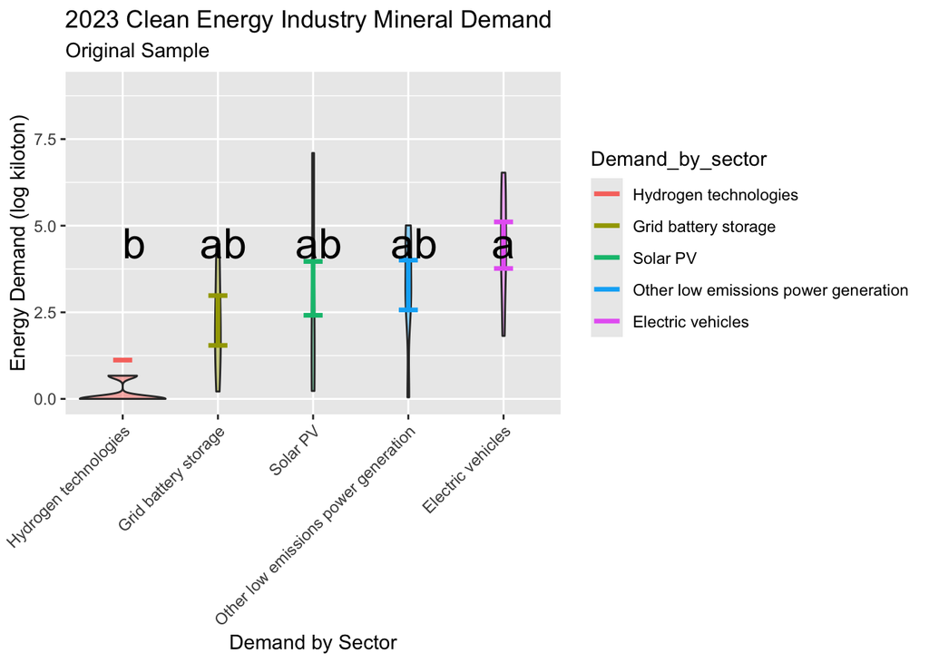

```r
pairwise_plot
```

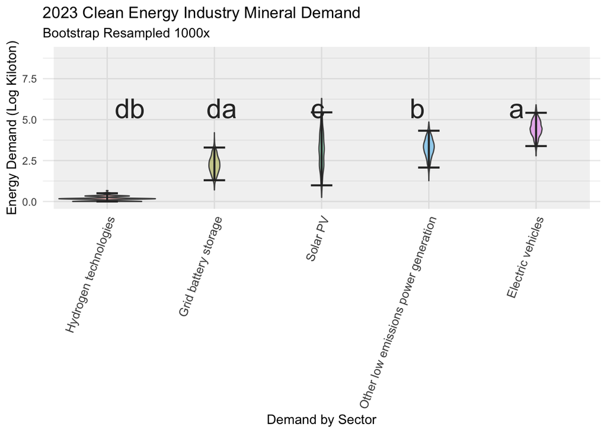

```r
pairwise_boot_plot
```

# Conclusion and Implications

The purpose of this study is to test the hypothesis whether clean energy industries differ in the abundance of minerals needed to accomplish their goals in reducing carbon emissions. Testing this hypothesis is useful because the focus of the dataset is projecting the future mineral demand for these industries, so using real data for statistical analysis will allow quantitative assessments of how reasonable their projections are. In conclusion, we have found that from our linear model the hydrogen technology industry has the lowest demand for minerals and the electric vehicle industry has the highest demand for minerals and these categories are sufficiently different when compared to null distributions both in the raw dataset and bootstrapped.

Upon first observation of the raw dataset, the sampling of industries showed to be highly variable in their mineral demand ranging from very low to very high in their need for minerals, but the ANOVA test and post hoc only indicated that mineral demand can only be predicted with confidence if it is either the electric vehicle industry or the hydrogen technology industry and the rest cannot be distinguished from a null distribution.

Some shortcomings to this statistical analysis is that this analysis excludes industries electricity networks and low emissions power generation which also may be significantly different in their demand than other industries but were not tested in the analysis since an ANOVA test requires more than one data point. This dataset is also not representative of global use, and it is not specified from what company or region they are from. Finally, the values used to calculate the response variables are approximated by the IEA from consulting World Energy Outlook, Energy Technology Perspectives, and Global EV Outlook journals as sources and are not direct measurements.

# My personal takeaways

My personal biggest insight with this project alongside learning post hoc tests, linear modeling with mutiple categorical variables and analysis, is how analyzing small sample sizes leads to vulnerability in generating false positive artifacts that may be misleading. Bootstrapping is a great tool kit to have when the data at hand is limited in sample size!